# Final Project

11th May 2021

## Outline

- Introduction
- Materials
  - Description of data set
- Methods
  - Data wrangling, visualization and modelling
- Results
- Discussion and Conclusion

## Introduction

## Introduction

- Prostate cancer data set, Andrews DF and Herzberg AM (1985)
- Compare four different treatments
- 502 observations of 18 variables
- 27 NA values

## Materials

### The Data set

## The Raw Data set

Variables in the data set, 1/2

Variable

Desription

Level / Summary Statistic

patno

Patient number

stage

Stage of prostate cancer

3 or 4

rx

Dosage of estrogen treatment in mg

Placebo, 0.2 mg, 1.0 mg, 5.0 mg

status

Status of the patient, alive or or cause of death

alive, dead - prostatic ca, dead - heart or vascular, dead - cerebrovascular, dead - pulmonary embolus, dead - other ca, dead - respiratory disease, dead - other specific non-ca, dead - unspecified non-ca, dead - unknown cause

hx

History of Cardiovascular Disease

Yes/No

ekg

Electrocardiography

normal, benign, rhythmic disturb & electrolyte ch, heart block or conduction def, heart strain, old MI, recent MI

pf

Activity level based on time in bed

normal activity, in bed < 50% daytime, in bed > 50% daytime, confined to bed

## The Raw Data set

Variables in the data set, 2/2

Variable

Desription

Level / Summary Statistic

age

Age of patient in years

71.51 (48.00 ~ 89.00)

wt

Weight Index = wt(kg)-ht(cm)+200

98.93 (69.00 ~ 152.00)

sbp

Systolic Blood Pressure/10

14.35 (8.00 ~ 30.00)

dbp

Diastolic Blood Pressure/10

8.15 (4.00 ~ 18.00)

hg

Serum Hemoglobin [g/100ml]

13.45 (5.90 ~ 21.20)

ap

Serum Prostatic Acid Phosphatase

12.18 (0.01 ~ 999.88)

sz

Size of Primary Tumor [cm^2]

14.57 (0.00 ~ 69.00)

bm

The presence of Bone Metastases

Yes/No

sg

Combined Index of Stage and Hist. Grade

sdate

Date of study

dtime

Months of Follow-up

## Methods

## Methods - Data cleaning and wrangling

#### **Raw data to Clean data**

- Exclude *dtime*, *sdate* and *sg*
- Renaming variables

#### **Clean data to Augment data**

- Add six new variables:
  - outcome = mutating *status* into alive vs dead
  - treatment_mg = making a numeric variable by removing string
  - EKG_lvl = creating a factorized variable with the levels in numbers
  - performance_lvl = creating a factorized variable with the levels in numbers
  - age_group = forming two age groups young/old based on the mean
  - acid_phosphatase_log = log transforming the *acid phosphatase*

## Methods

### Visualization of pre-treatment variables

## Methods

### Visualization of pre-treatment variables - Numeric

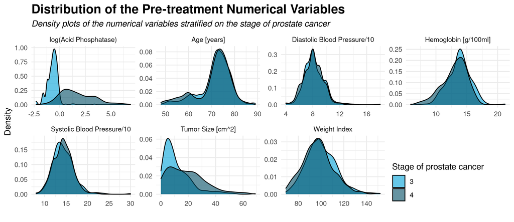

## Methods

### Visualization of pre-treatment variables - Categorical

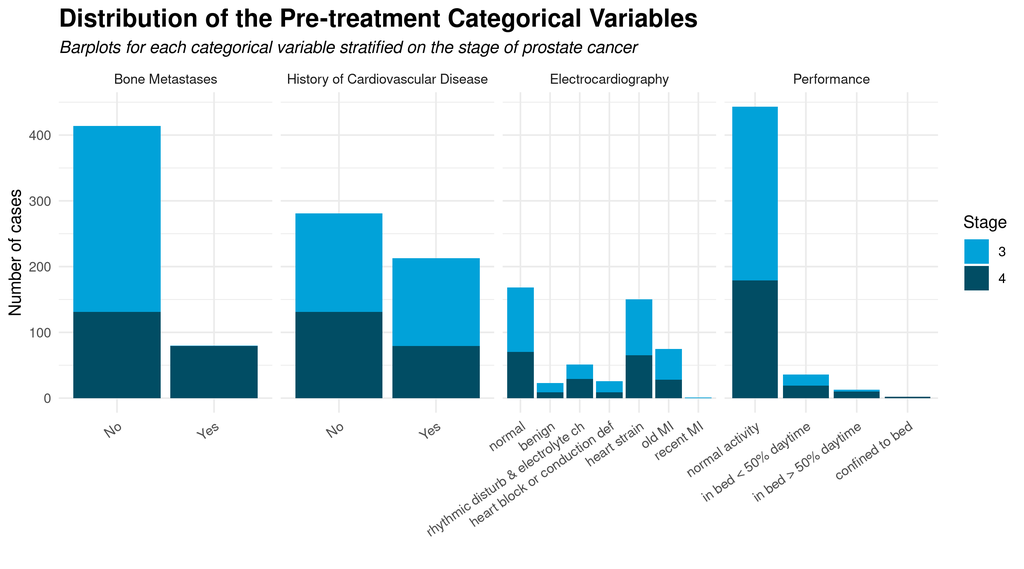

## Methods

### Visualization of pre-treatment variables - Heatmap

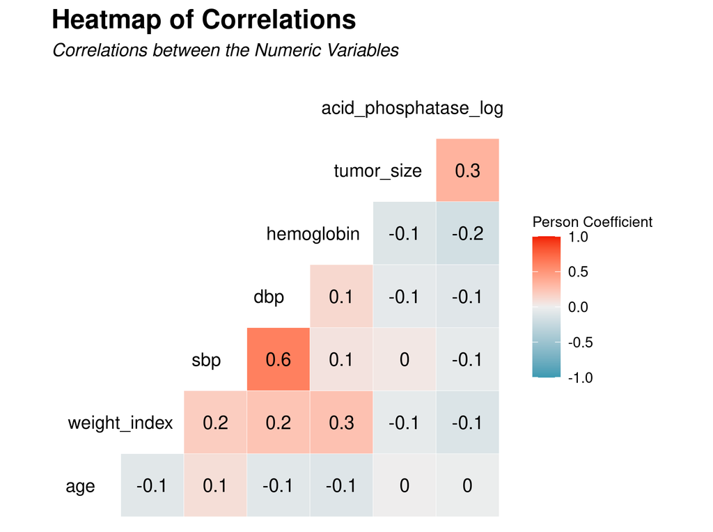

## Methods

### Modelling

- Logistic regression
- PCA
- K-means clustering

## Results

## Results

### Treatment, outcome and age

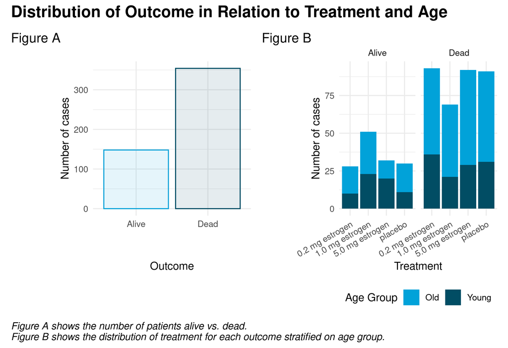

## Results

### Logistic model - Outcome as function of treatment

Output:

```r
log_mod_treatment
```

```
## # A tibble: 4 x 5
##   term            estimate std.error statistic     p.value
##   <chr>              <dbl>     <dbl>     <dbl>       <dbl>
## 1 (Intercept)       1.11       0.211     5.27  0.000000136
## 2 treatment_mg0.2   0.0907     0.301     0.301 0.763
## 3 treatment_mg1    -0.807      0.280    -2.88  0.00394
## 4 treatment_mg5    -0.0536     0.294    -0.182 0.855
```

## Results

### Logistic model for each variable - Treatment = 1.0 mg

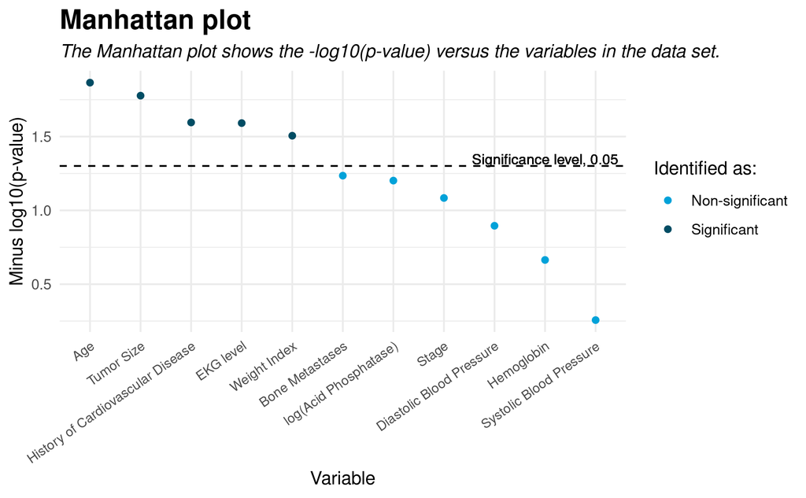

## Results

### Logistic model for each variable - Treatment = 1.0 mg

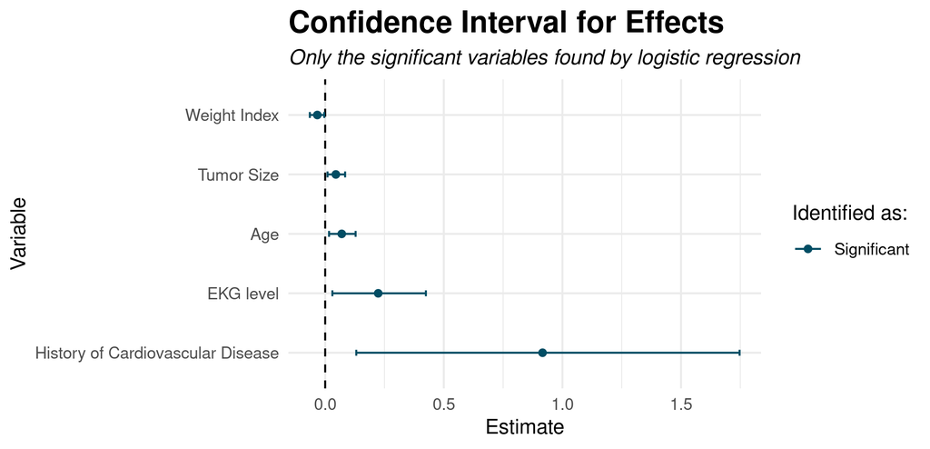

## Results

### Distribution of significant variables for each outcome

[figure not shown]

## Results

### Principal Component Analysis

## Results

### Principal Component Analysis

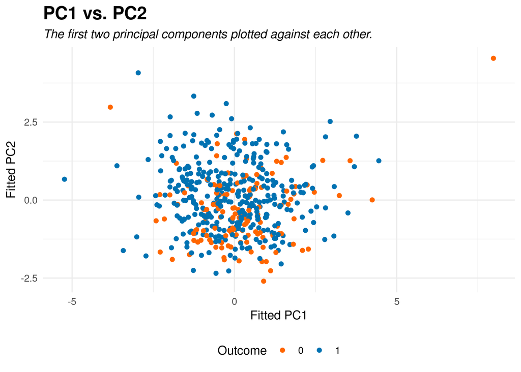

## Results

### Principal Component Analysis

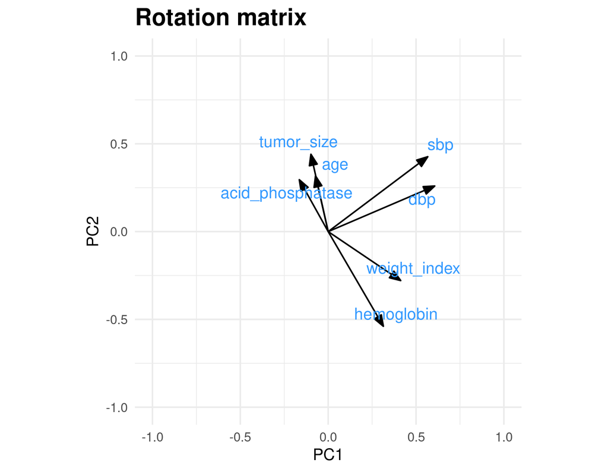

## Results

### Principal Component Analysis

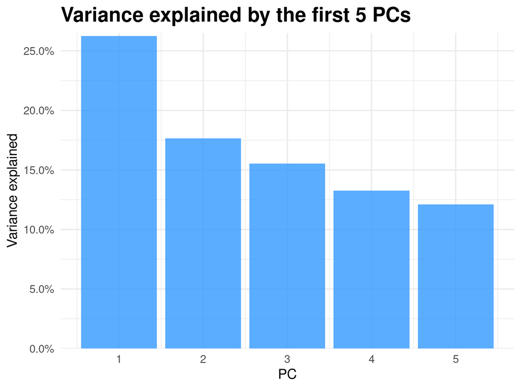

## Results

### K-means clustering

## Results

### K-means clustering

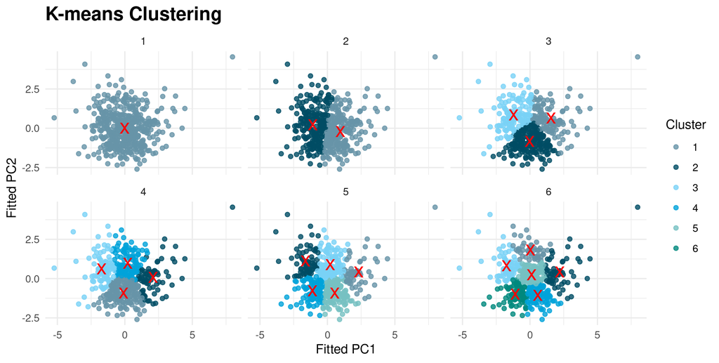

## Results

### K-means clustering

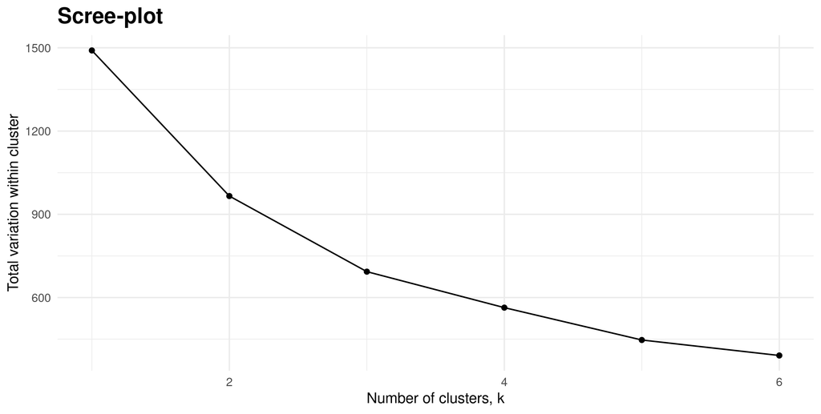

## Results

### K-means clustering

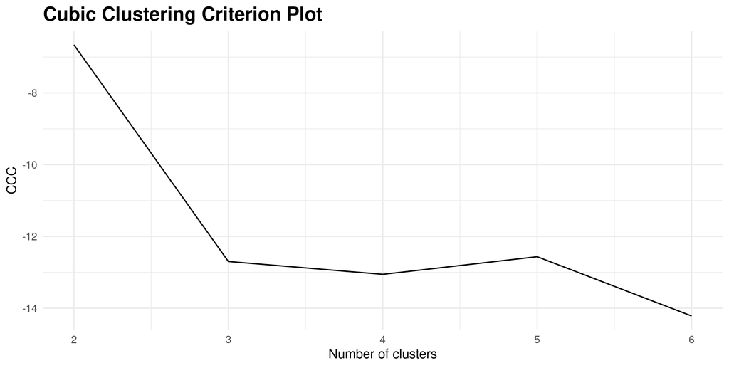